# Estimation of the power-law depencence between the $log_{10}-log_{10}$ SD of interaction frequencies and distance between interacting regions

John Stansfield, Mikhail Dozmorov

# Introduction

To estimate the parameters for simulating individual Hi-C matrices, Hi-C data from Gm12878 cell line [@Rao:2014aa] were used (Supplementary Table 1, GSE63525). The first dataset was obtained with DpnII restriction enzyme, while the second dataset was obtained with the MboI enzyme. Data from chromosome 1 was used at resolutions of 1Mb, 500kb, 100kb, and 50kb. The data were converted in a sparse matrix format (see `HiCdiff-vignette.Rmd` for details). Additional Gm12878 Hi-C data from chrs 1, 18, and 19 at 1Mb resolution, cut using the DpnII and MboI enzymes were also included.

# SD of IFs vs. distance dependence

First, we estimate the power-law approximation of the dependence between the standard deviation (SD) of interaction frequencies (IFs) and distance by fitting the power-law estimate and assessing the fit using Kolmogorov-Smirnov test. Because SDs at larger distances do not fit the power-law well the outlier values are iteratively removed, starting from largest distances, until Kolmogorov-Smirnov test results indicate the power-law fit is adequate. The $\alpha$ power-law parameter can then be used to approximate the decay of SD with distance.

As with the decay of IFs with distance, the power-law approximation can be affected by multiple factors, e.g., the resolution of the data, the enzymes used to obtain the data, the chromosomal differences (e.g., chromosome length (chromosome 1 being the longest), gene density (gene-poor chromosome 18 and gene-dense chromosome 19)).

## The effect of resolution

Tables show the output of `fitdistplus::power.law.fit` function. Key variables to note are `alpha` - the power of the $C*x^{-alpha}$ power-law formula, and `KS.p` - p-value of the Kolmogorov-Smirnov test, larger p-value means that the power-law fit is adequate. The first row is for DpnII and the second row is for MboI.

The plots represent the log10(SD) vs log10(Distance), one plot per cutting enzyme.

### 1 MB

| Enzyme | continuous | alpha | xmin | logLik | KS.stat | KS.p |
| --- | --- | --- | --- | --- | --- | --- |
| DpnII | TRUE | 2.331709 | 42.20044 | -494.6538 | 0.04391755 | 0.9925585 |
| MboI | TRUE | 2.365061 | 750.7263 | -353.8661 | 0.07215841 | 0.9732388 |

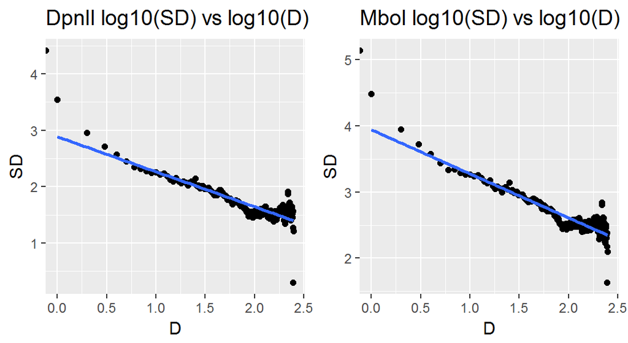

### 500KB

| Enzyme | continuous | alpha | xmin | logLik | KS.stat | KS.p |
| --- | --- | --- | --- | --- | --- | --- |
| DpnII | TRUE | 2.334898 | 11.89302 | -720.3278 | 0.0427384 | 0.8899287 |
| MboI | TRUE | 2.231429 | 105.525 | -1133.574 | 0.06889731 | 0.3533398 |

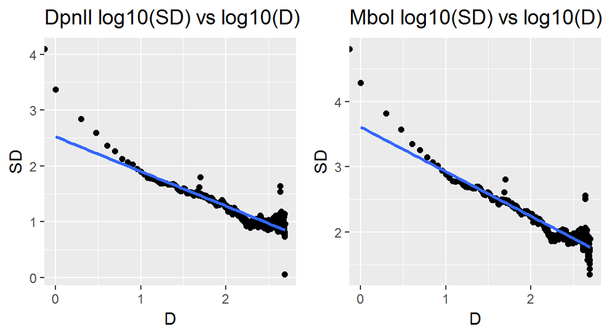

### 100KB

| Enzyme | continuous | alpha | xmin | logLik | KS.stat | KS.p |
| --- | --- | --- | --- | --- | --- | --- |
| DpnII | TRUE | 1.729765 | 7.062814 | -153.126 | 0.03494209 | 1 |
| MboI | TRUE | 1.857958 | 28.9925 | -409.3773 | 0.04058937 | 0.9997465 |

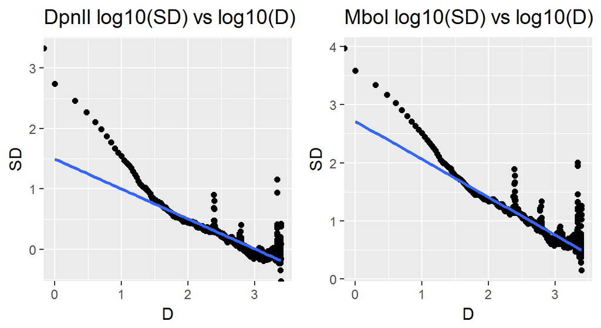

### 50KB

| Enzyme | continuous | alpha | xmin | logLik | KS.stat | KS.p |
| --- | --- | --- | --- | --- | --- | --- |
| DpnII | TRUE | 1.757461 | 3.343024 | -175.0236 | 0.03571082 | 1 |
| MboI | TRUE | 1.791732 | 14.98267 | -400.6679 | 0.0302201 | 0.9999997 |

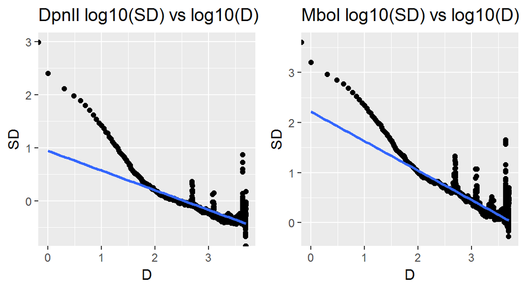

## The effect of chromosomes

Here the fit to the power-law of SD of IF at each distance is tested for chromosome 1, 18, 19 from GM12878 cell line using cutting enzymes DpnII and MboI at 1MB resolution.

As above, the table shows the output of `fitdistplus::power.law.fit` function. Key variables to note are `alpha` - the power of the $C*x^{-alpha}$ power-law formula, and `KS.p` - p-value of the Kolmogorov-Smirnov test, larger p-value means that the power-law fit is adequate. The plots represents the log10(SD) and log10(Distance), one plot for each cutting enzyme.

### Chr 1

| Enzyme | continuous | alpha | xmin | logLik | KS.stat | KS.p |
| --- | --- | --- | --- | --- | --- | --- |
| DpnII | TRUE | 2.336356 | 42.17819 | -494.0248 | 0.04407543 | 0.9922233 |
| MboI | TRUE | 2.247001 | 55.16459 | -514.4183 | 0.06870571 | 0.7722857 |

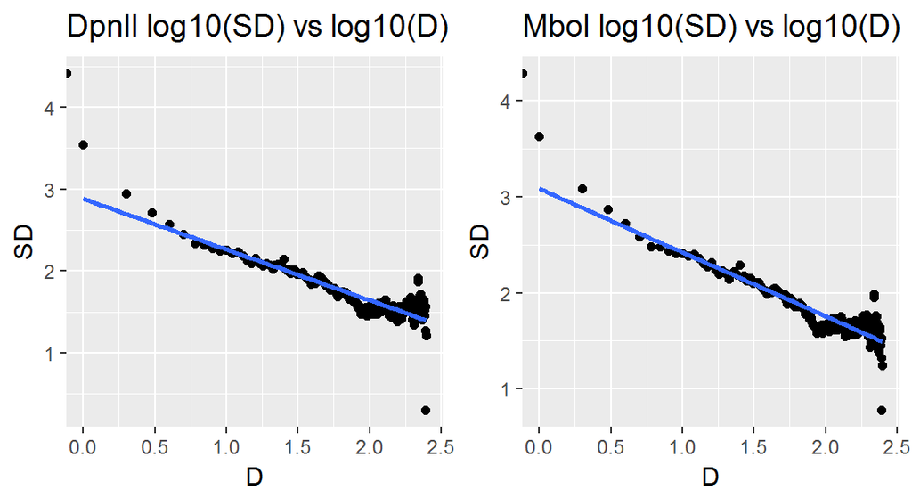

### Chr 18

| Enzyme | continuous | alpha | xmin | logLik | KS.stat | KS.p |
| --- | --- | --- | --- | --- | --- | --- |
| DpnII | TRUE | 1.797929 | 193.6994 | -69.70759 | 0.09225675 | 0.9999956 |
| MboI | TRUE | 1.822987 | 262.2809 | -71.81386 | 0.09429987 | 0.9999921 |

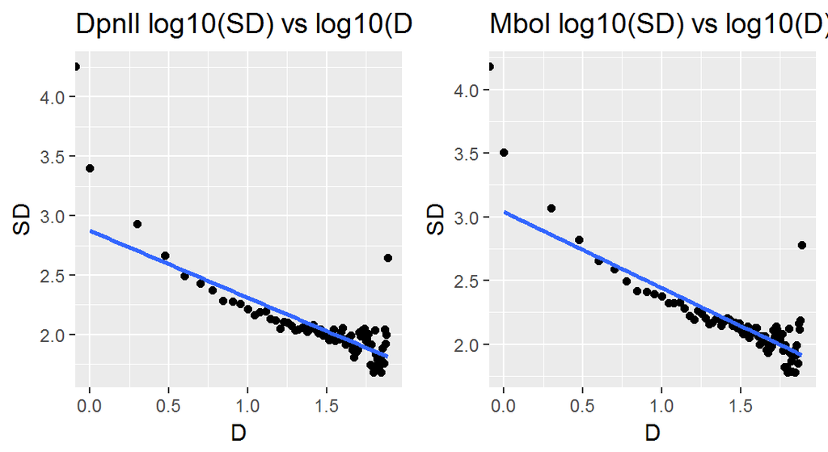

### Chr 19

| Enzyme | continuous | alpha | xmin | logLik | KS.stat | KS.p |
| --- | --- | --- | --- | --- | --- | --- |
| DpnII | TRUE | 1.826717 | 363.6522 | -66.36875 | 0.102455 | 0.9999826 |
| MboI | TRUE | 1.904656 | 576.7541 | -68.50406 | 0.1064836 | 0.9999559 |

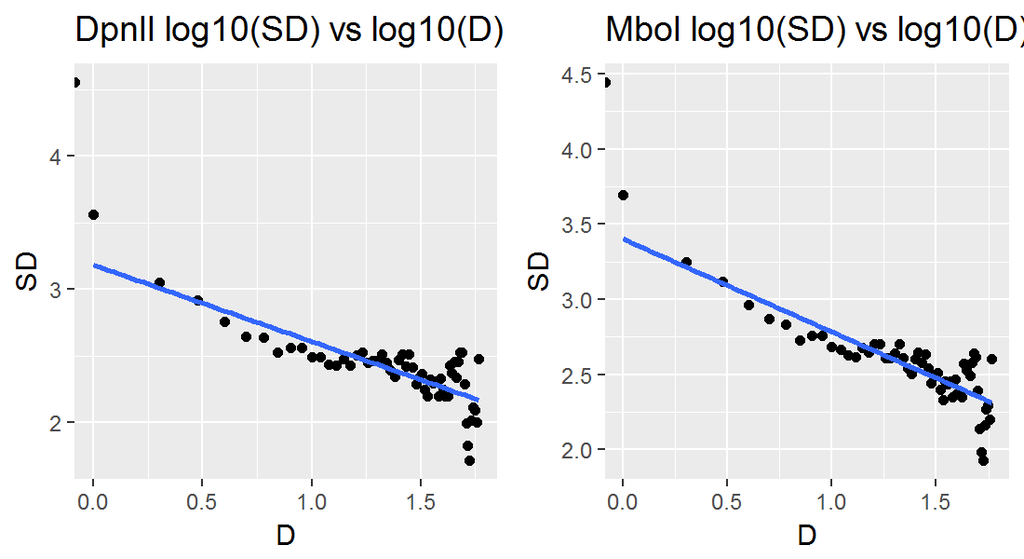